# 💀 03 Baseline Mortality Model

| Title | 03 Baseline Mortality Model |
| --- | --- |
| Case Study | Climate-Adjusted Mortality for Selected EU Countries |
| Research Project | CC230 Quantifying Mortality and Morbidity Impacts from Climate Risks |
| Notebook | `03_baseline_mortality_model.ipynb` |
| Authors | Carlos Arocha, FSA, SCR |
| Sponsor | Catastrophe and Climate Strategic Research Program, Society of Actuaries Research Institute |
| Date | `2026-05-11` |
| Version | `v1.0.0` |
| Questions? | Questions regarding this notebook should be directed to the SOA project contact |

## Purpose

Estimate the non-climate mortality structure before introducing $C_{t,r}$, using the reduced form of the Climate-Adjusted Lee-Carter Mortality Model (cf. `Quantifying Mortality and Morbidity Impacts for Climate Risks` report):

$\log{m_{x, t, r}}=a_{x, r} + b_xk_t+\lambda_{x, r}C_{t, r}+\epsilon_{x, t, r}$

In this notebook, we will focus only on $a_{x, r}$, $b_x$. and $k_t$ and leave $\lambda_{x, r}$ and $C_{t,r}$ for the next notebook (i.e., `04_climate_calibration.ipynb`.)

NOTE: Inputs depend on the scenario selected in Notebook `01_data_ingestion_and_preparation.ipynb`

- `CC230 Toolkit/data/processed/mortality/mortality_country_age_year_2004_2025_excl_2020_2021_age20_85.csv`
- `CC230 Toolkit/config/model_config.yaml`

## Outputs

Report:

- `CC230 Toolkit/reports/{NOTEBOOK}.html`

## Dependencies

This notebook can be run in Google Colab or any compatible Jupyter environment, such as:

- JupyterLab
- Jupyter Notebook
- VS Code with the Jupyter extension
- Anaconda Navigator
- Kaggle Notebooks

The notebook was developed using:

- Python 3.14.5
- Required libraries installed through the setup cell below

## Disclaimer

The Jupyter notebooks available through this repository are provided for research, educational, and illustrative purposes only. They are not intended to constitute actuarial advice or to represent production-ready systems without further validation, customization, and governance by the user.

While reasonable efforts have been made to ensure accuracy and consistency, no guarantee is given as to completeness, fitness for a particular purpose, or compliance with applicable actuarial standards or regulatory requirements.

Users are responsible for assessing the suitability of the materials for their specific use cases and for implementing appropriate controls, validation, and documentation prior to any operational use.

## License

© 2026 Society of Actuaries. Except where otherwise noted, the textual content of this book is licensed under the Creative Commons Attribution–Noncommercial–Share Alike 4.0 International License (CC BY-NC-SA 4.0). Source code samples, including scripts, notebooks, and code blocks where indicated, are licensed under the MIT License, unless otherwise stated.

## Setup and Shared Configuration

```
Loaded control files:
 - run_config.json
 - input_manifest.csv
 - 01_data_ingestion_and_preparation_output_manifest.csv
 - 02_climate_features_output_manifest.csv
```

## Settings Imported from Notebook 01

```
{
  "notebook": "03_baseline_mortality_model.ipynb",
  "run_timestamp_utc": "2026-07-21T07:06:41.116691+00:00",
  "project_root": "C:\\Users\\ca\\OneDrive\\Documents\\@ PROJECTS\\CC230-Toolkit",
  "scenario": "ssp5_8_5",
  "countries": [
    "ES",
    "FR",
    "IT"
  ],
  "calibration_years": [
    2004,
    2005,
    2006,
    2007,
    2008,
    2009,
    2010,
    2011,
    2012,
    2013,
    2014,
    2015,
    2016,
    2017,
    2018,
    2019,
    2022,
    2023,
    2024,
    2025
  ],
  "age_min": 20,
  "age_max": 85
}
Mortality input file: country_age_year_2004_2025_excl_2020_2021_age20_85.csv
```

## Helper Functions

```
Required Notebook 3 input file was found.
```

## Load and Validate Mortality Dataset

The baseline mortality model uses the processed mortality file created by Notebook 01. The expected columns are `country`, `year`, `age`, and `mx`.

```
Countries: ['ES', 'FR', 'IT']
Calibration years: 2004 to 2025
Excluded calibration years: [2020, 2021]
Age range: 20.0 to 85.0
Rows after preparation: 3960
All expected country-year combinations are present.
```

## Estimate $b_x$ and $k_t$

The centered mortality matrix is constructed by averaging centered log mortality across countries for each age-year cell. Singular value decomposition (SVD) is then used to estimate the first Lee-Carter age sensitivity vector $b_x$ and time index $k_t$.

```
LC calibration years requested: [2004, 2005, 2006, 2007, 2008, 2009, 2010, 2011, 2012, 2013, 2014, 2015, 2016, 2017, 2018, 2019, 2022, 2023, 2024, 2025]
LC excluded years: [2020, 2021]
LC years expected in SVD: [2004, 2005, 2006, 2007, 2008, 2009, 2010, 2011, 2012, 2013, 2014, 2015, 2016, 2017, 2018, 2019, 2022, 2023, 2024, 2025]
LC years actually used in SVD: [2004, 2005, 2006, 2007, 2008, 2009, 2010, 2011, 2012, 2013, 2014, 2015, 2016, 2017, 2018, 2019, 2022, 2023, 2024, 2025]
LC matrix shape: (66, 20)
Number of ages: 66
Number of SVD years: 20
```

```
Sum of b_x: 1.000
Mean of centered k_t: -0.000
```

```
b_x diagnostics
```

```
count    66.000000
mean      0.015152
std       0.005228
min       0.007222
1%        0.007366
5%        0.007923
25%       0.010479
50%       0.013556
75%       0.019868
95%       0.023465
99%       0.025313
max       0.027065
Name: b_x, dtype: float64
```

```
Sum of b_x: 1.0
Min b_x: 0.007222264733534511
Max b_x: 0.027065368019014283
Number of negative b_x values: 0
Number of ages: 66
```

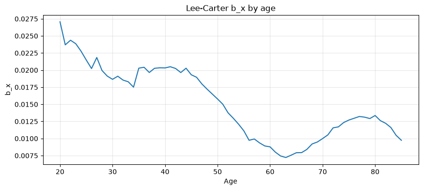

```
Range of b_x * k_t:
Minimum: -0.44773673504809497
Maximum: 0.43379951489038865
```

```
count    1.320000e+03
mean    -6.476301e-18
std      1.451142e-01
min     -4.477367e-01
1%      -3.375000e-01
5%      -2.257834e-01
25%     -8.291371e-02
50%     -3.230941e-02
75%      9.617033e-02
95%      2.574797e-01
99%      3.269943e-01
max      4.337995e-01
Name: b_x_k_t, dtype: float64
```

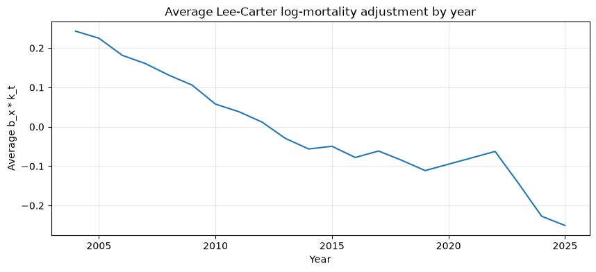

|  | singular_value | variance_share | cumulative_share |
| --- | --- | --- | --- |
| 0 | 5.270264 | 0.967410 | 0.967410 |
| 1 | 0.665487 | 0.015425 | 0.982835 |
| 2 | 0.313213 | 0.003417 | 0.986252 |
| 3 | 0.286672 | 0.002862 | 0.989115 |
| 4 | 0.250693 | 0.002189 | 0.991304 |
| 5 | 0.220590 | 0.001695 | 0.992998 |
| 6 | 0.194303 | 0.001315 | 0.994313 |
| 7 | 0.170464 | 0.001012 | 0.995325 |
| 8 | 0.162495 | 0.000920 | 0.996245 |
| 9 | 0.151458 | 0.000799 | 0.997044 |

```
First component variance share: 0.9674104596583006
```

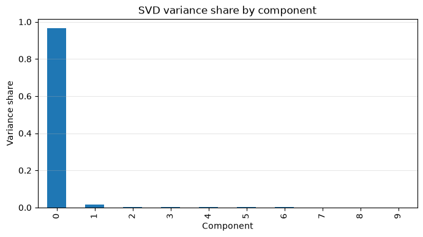

## Fitted Values and Residuals

The final $a_{x,r}$ parameter is adjusted to reflect the centering of $k_t$. The fitted baseline log mortality rate is then calculated as $\log \hat{m}^{\,base}_{x,t,r} = a_{x,r} + b_x k_t$.

## Save Outputs and Write Notebook 03 Manifest

The outputs form this notebook are used by Notebook 04 to calibrate the climate-related mortality component.

```
Saved baseline model outputs:
  - baseline_parameters_a_xr_2004_2025_excl_2020_2021_age20_85.csv
  - baseline_parameters_b_x_2004_2025_excl_2020_2021_age20_85.csv
  - baseline_parameters_k_t_2004_2025_excl_2020_2021_age20_85.csv
  - baseline_fitted_mortality_2004_2025_excl_2020_2021_age20_85.csv
  - baseline_residuals_2004_2025_excl_2020_2021_age20_85.csv
  - baseline_residual_diagnostics_2004_2025_excl_2020_2021_age20_85.csv
```

[output not shown]